# Intensified Emotions due to Immersive 3D Audio? Reanalysis of Data From a Study by Hahn (2018) on the Emotional Effects of Music Presented in Various Audio Formats

Kilian Sander, Yves Wycisk, Reinhard Kopiez

2022

# Data set from Hahn (2018)

## Preparation

### Data, Packages, and Design

Load the data:

```r
load("data/data_raw.Rda")
```

Load relevant packages:

```r
sapply(c("tidyverse", "MANOVA.RM", "rstatix", "ggpubr"), require, character.only = T)
```

Prepare the design with vectors:

```r
formats <- c("stereo", "surround", "auro")
gems_factors <- c("wonder", "transcendence", "tenderness", "nostalgia",
                  "peacefulness", "power", "joyful_activation", "tension",
                  "sadness")
# item to factor mapping
wonder <- c("moved", "filled_with_wonder", "allured")
transcendence <- c("feeling_of_transcendence", "fascinated", "overwhelmed")
tenderness <- c("affectionate", "tender", "mellowed")
nostalgia <- c("sentimental", "dreamy", "nostalgic")
peacefulness <- c("calm", "serene", "soothed")
power <- c("energetic", "triumphant", "strong")
joyful_activation <- c("joyful", "animated", "bouncy")
tension <- c("agitated", "nervous", "tense")
sadness <- c("sad", "sorrowful", "tearful")
```

### Filtering

Exclude a participant if there are at least two `NA`s for a GEMS factor of one stimulus:

```r
data_raw$complete <- TRUE
for (p in data_raw$participant) {
  part_data <- data_raw %>% filter(participant == p)
  for (excerpt in c("a", "b")) {
    for (format in formats) {
      for (factor in gems_factors) {
        temp_data <- part_data %>%
          dplyr::select(starts_with(paste(excerpt, format, get(factor), sep = "_")))
        nas <- temp_data %>% t() %>% is.na() %>% sum()
        if (nas > 1) {
          data_raw$complete[p] <- FALSE
        }
      }
    }
  }
}
rm(part_data, temp_data, nas, p, format, excerpt)
data_filtered <- data_raw %>% filter(complete==TRUE)
N <- length(data_filtered$participant)
```

After removing incomplete cases the data set contains 52 participants.

### Scoring

Calculate mean values for each item per format:

```r
for (format in formats) {
  for (factor in gems_factors) {
    for (item in get(factor)) {
      item_mean_vector <- data_filtered %>%
        select(ends_with(paste0(format, "_", item))) %>%
        rowMeans(na.rm = TRUE)
      eval(str2expression(paste0("data_filtered$",
                                 format, "_", item,
                                 " <- item_mean_vector")))
    }
  }
}
rm(item, item_mean_vector)
data_filtered <- data_filtered %>% mutate_all(~ifelse(is.nan(.), NA, .))
```

Calculate the mean of each factor per format across its items:

```r
for (format in formats) {
  for (factor in gems_factors) {
    factor_mean_vector <- data_filtered %>%
      select(paste0(format, "_", get(factor))) %>%
      rowMeans(na.rm = TRUE)
    eval(str2expression(paste0("data_filtered$",
                                 format, "_", factor,
                                 " <- factor_mean_vector")))
  }
}
rm(format, factor, factor_mean_vector)
```

### Long format

```r
vars_vector <- sapply(formats,
                      function(format) {
                        paste0(format, "_", gems_factors)
                      },
                      USE.NAMES = F) %>% as.vector()
data_long_mult <- data_filtered %>% select(participant, all_of(vars_vector))
names(data_long_mult) <- names(data_long_mult) %>%
  gsub("joyful_activation", "joyfulactivation", .)
data_long_mult <- data_long_mult %>%
  pivot_longer(!participant,
               names_to = c("format", ".value"),
               names_pattern = "(.*)_(.*)")
data_long_single <- data_long_mult %>%
  pivot_longer(!c(participant, format),
               values_to = "score",
               names_to = "factor") %>%
  mutate(factor = recode(factor,
                         joyfulactivation = "joyful activation") %>% tools::toTitleCase(),
         format = format %>% tools::toTitleCase() %>% as_factor())
names(data_long_mult) <- names(data_long_mult) %>%
  gsub("joyfulactivation", "joyful_activation", .)
data_long_mult$format <- data_long_mult$format %>% as_factor()
```

## Analyses

### Descriptives

Out of the 52 participants 17 indicated “female” as their gender whereas 35 indicated “male”. The participants’ age ranged from 15 to 69 with a mean of 30.1346154 (*SD* = 12.4601779).

| GEMS Factor | Format | $M$ | $SD$ |
| --- | --- | --- | --- |
| Joyful Activation | Stereo | 2.189103 | 0.5649810 |
| Joyful Activation | Surround | 2.285256 | 0.5980511 |
| Joyful Activation | Auro | 2.336539 | 0.6072281 |
| Nostalgia | Stereo | 2.333333 | 0.5977445 |
| Nostalgia | Surround | 2.410256 | 0.6538486 |
| Nostalgia | Auro | 2.490385 | 0.6504678 |
| Peacefulness | Stereo | 2.429487 | 0.6133466 |
| Peacefulness | Surround | 2.439103 | 0.6658728 |
| Peacefulness | Auro | 2.480769 | 0.5919337 |
| Power | Stereo | 2.272436 | 0.7691129 |
| Power | Surround | 2.384615 | 0.7302508 |
| Power | Auro | 2.480769 | 0.8680067 |
| Sadness | Stereo | 1.897436 | 0.6932242 |
| Sadness | Surround | 1.894231 | 0.6584699 |
| Sadness | Auro | 2.003205 | 0.7616133 |
| Tenderness | Stereo | 2.275641 | 0.5629101 |
| Tenderness | Surround | 2.336539 | 0.6695122 |
| Tenderness | Auro | 2.375000 | 0.6039765 |
| Tension | Stereo | 2.248397 | 0.6396678 |
| Tension | Surround | 2.342949 | 0.6763299 |
| Tension | Auro | 2.306090 | 0.6180653 |
| Transcendence | Stereo | 2.586539 | 0.7601817 |
| Transcendence | Surround | 2.769231 | 0.7577873 |
| Transcendence | Auro | 3.000000 | 0.8769625 |
| Wonder | Stereo | 2.692308 | 0.6981025 |
| Wonder | Surround | 2.823718 | 0.6855285 |
| Wonder | Auro | 2.996795 | 0.8565335 |

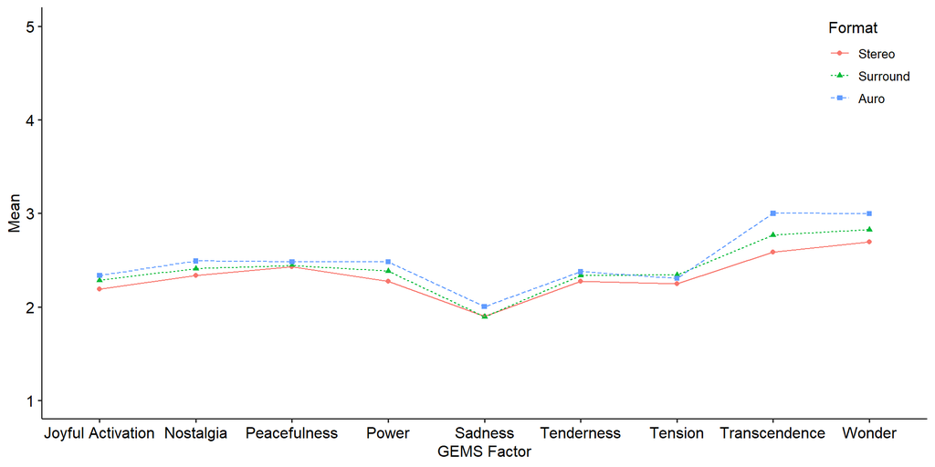

### Multivariate Analysis of Variance

```r
#rm_manova <-
#  multRM(formula = cbind(wonder, transcendence, tenderness,
#                         nostalgia, peacefulness, power,
#                         joyful_activation, tension, sadness) ~ format,
#         data = data_long_mult,
#         subject = "participant",
#         within = "format",
#         para = TRUE,
#         iter = 50000,
#         dec = 5,
#         seed = 987)
load(file = "results/rm_manova.Rda")
summary(rm_manova)
```

```
## Call:
## cbind(wonder, transcendence, tenderness, nostalgia, peacefulness,
##     power, joyful_activation, tension, sadness) ~ format
## A multivariate repeated measures analysis with  1 within-subject factor(s) ( format )and  0 between-subject factor(s).
##
## Descriptive:
##     format  n  wonder  transcendence  tenderness  nostalgia  peacefulness
## 1   stereo 52 2.69231        2.58654     2.27564    2.33333       2.42949
## 2 surround 52 2.82372        2.76923     2.33654    2.41026       2.43910
## 3     auro 52 2.99679        3.00000     2.37500    2.49038       2.48077
##     power  joyful_activation  tension  sadness
## 1 2.27244            2.18910  2.24840  1.89744
## 2 2.38462            2.28526  2.34295  1.89423
## 3 2.48077            2.33654  2.30609  2.00321
##
## Wald-Type Statistic (WTS):
##        Test statistic df   p-value
## format "40.78519"     "18" "0.00163"
##
## modified ANOVA-Type Statistic (MATS):
##        Test statistic
## format       17.90262
##
## p-values resampling:
##        paramBS (WTS) paramBS (MATS)
## format "0.14638"     "0.00386"
```

### Analysis of Variance for *Transcendence*

#### Assumption Checks

##### Extreme Outliers

```r
data_long_mult %>% group_by(format) %>%
  select(format, participant, transcendence) %>%
  identify_outliers(transcendence) %>%
  filter(is.outlier)
```

```
## # A tibble: 10 × 5
##    format   participant transcendence is.outlier is.extreme
##    <fct>          <int>         <dbl> <lgl>      <lgl>
##  1 stereo             1          1.33 TRUE       FALSE
##  2 stereo             6          1.17 TRUE       FALSE
##  3 stereo             8          4.17 TRUE       FALSE
##  4 stereo            11          1    TRUE       FALSE
##  5 stereo            43          1    TRUE       FALSE
##  6 surround           6          1.17 TRUE       FALSE
##  7 surround          11          1.17 TRUE       FALSE
##  8 surround          43          1.33 TRUE       FALSE
##  9 surround          47          4.67 TRUE       FALSE
## 10 surround          48          1.17 TRUE       FALSE
```

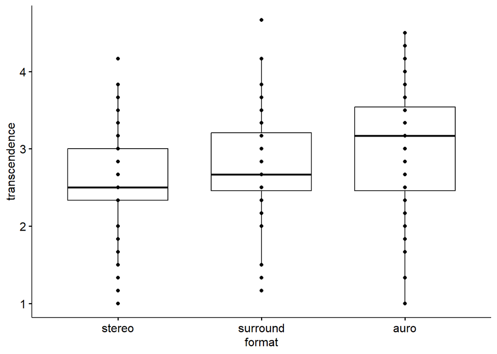

```r
ggboxplot(data_long_mult, x = "format", y = "transcendence", add = "point")
```

##### Normality: Shapiro-Wilk Test and QQ-Plots

| Version | Test Statistic | $p$ |
| --- | --- | --- |
| stereo | 0.9719007 | 0.2539826 |
| surround | 0.9624311 | 0.0997768 |
| auro | 0.9670579 | 0.1581975 |

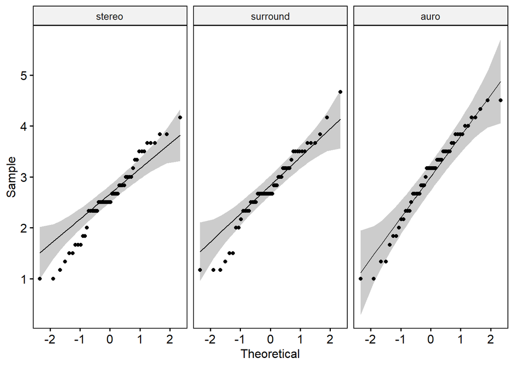

##### Mauchly’s Test for Sphericity

```r
transcendence_anova <-
  anova_test(data = data_long_mult,
             dv = transcendence,
             wid = participant,
             within = format,
             type = 3,
             effect.size = "pes")
transcendence_ges <- anova_test(data = data_long_mult,
           dv = transcendence,
           wid = participant,
           within = format,
           type = 3,
           effect.size = "ges")$ANOVA$ges
transcendence_anova$`Mauchly's Test for Sphericity` %>%
  knitr::kable(col.names = c("Effect", "$W$", "$p$", "$p<.05$"),
               align = "lccc")
```

| Effect | $W$ | $p$ | $p<.05$ |
| --- | --- | --- | --- |
| format | 0.931 | 0.169 |  |

#### Results

| Effect | DFn | DFd | $F$ | $p$ | $\eta^2_p$ | $\eta^2_G$ |
| --- | --- | --- | --- | --- | --- | --- |
| format | 2 | 102 | 13.209 | 7.9e-06 | 0.206 | 0.044 |

[figure not shown]

*Note.* Error bars represent 95% confidence intervals. GEMS factors are on a 5-point Likert scale coded from 1 to 5. Plot was exported from JASP (JASP Team, 2021).

| Contrasts | Estimate | CI LL | CI UL | SE | df | $t$ | $p$ |
| --- | --- | --- | --- | --- | --- | --- | --- |
| Surround – Stereo | 0.183 | 0.023 | 0.343 | 0.081 | 102 | 2.266 | 0.026 |
| Auro – Stereo | 0.413 | 0.254 | 0.573 | 0.081 | 102 | 5.128 | 1.397e-6 |
| Auro – Surround | 0.231 | 0.071 | 0.391 | 0.081 | 102 | 2.862 | 0.005 |

*Note.* Contrasts were calculated in JASP (JASP Team, 2021).

### Correlations for *Transcendence*

#### Correlations Between the Formats

| Formats | $r$ | $p$ | CI LL | CI UL | Fisher’s $z$ |
| --- | --- | --- | --- | --- | --- |
| Stereo – Surround | 0.7010 | < .001 | 0.5610 | 1 | 0.8692 |
| Stereo – Auro | 0.7018 | < .001 | 0.5621 | 1 | 0.8709 |
| Surround – Auro | 0.8163 | < .001 | 0.7215 | 1 | 1.1457 |

#### Average Correlation

To get a mean correlation individual correlation coefficients have to be Fisher $z$-transformed (Corey et al., 1998). The Fisher $z$-transformation is equivalent to the inverse hyperbolic tangent.

```r
avg_cor_z <- mean(cor_table$`Fisher's z`)
avg_cor_r <- tanh(avg_cor_z)
```

Taking the averaged Fisher $z$-transformed values results in a value of 0.9619. Back-transformed to Person’s $r$ the average correlation between the three audio formats for the GEMS factor Transcendence is 0.7451.

### Common Language Effect Sizes for *Transcendence*

The common language effect size (CLE) expresses “the probability that an individual has a higher value on one measurement than the other” (Lakens, 2013, p. 4). The CLE is therefore the probability that a $Z$-score is greater than a specific $Z_{\textrm{CLE}}$ (given a standard normal distribution). For repeated measures the $Z_{\textrm{CLE}}$ is calculated from the means and standard deviations from two measurements as well as their correlation (McGraw & Wong, 1992):
$$Z_{\textrm{CLE}} =
\frac{M_2 -
M_1}{\sqrt{SD_1^2+SD_2^2-2\cdot{}SD_1\cdot{}SD_2\cdot{}r_{12}}}$$

```r
get_cle <- function(mean1, mean2, sd1, sd2, r12) {
  Z_cle <- (mean2 - mean1) / sqrt(sd1^2 + sd2^2 - 2 * sd1 * sd2 * r12)
  Z_cle %>% pnorm(lower.tail = F)
}
```

```r
cle_table <- data.frame(format1 = c("Auro", "Auro", "Surround"),
                        format2 = c("Surround", "Stereo", "Stereo"))
cle_table$cle <-
  mapply(function(f1, f2) {
    desc <- descriptives %>% filter(factor == "Transcendence")
    get_cle(mean1 = desc$M[desc$format == f1],
            mean2 = desc$M[desc$format == f2],
            sd1 = desc$SD[desc$format == f1],
            sd2 = desc$SD[desc$format == f2],
            r12 = cor_table$r[cor_table$Formats == paste(f2, f1,
                                                         sep = " -- ")])
  },
  cle_table$format1, cle_table$format2)
cle_table %>% mutate(across(where(is.numeric), round, digits = 4)) %>%
  knitr::kable(col.names = c("Format 1", "Format 2", "CLE"),
               align = "llc")
```

| Format 1 | Format 2 | CLE |
| --- | --- | --- |
| Auro | Surround | 0.6751 |
| Auro | Stereo | 0.7405 |
| Surround | Stereo | 0.6222 |

Using the correction formula for multiple groups from McGraw & Wong (1992), the CLE for higher values in Auro than in Stereo and Surround is:

```r
p_auro <- .88 * prod(cle_table$cle[cle_table$format1 == "Auro"]) + .11
p_auro
```

```
## [1] 0.5498967
```

Thus, the probability that a random participant scored higher in Auro than in Stereo and Surround is 54.99%.

# Data set from Wycisk et al. (2022)

## Preparation

Load the outlier-adjusted data from Wycisk et al. (2022) containing *N* = 190 participants. Then calculate the IMEI score, i.e., the average of the ten items, as well as the mean IMEI score per audio format.

```r
imei_data <- read.csv("data/imei_data_outlier_adjusted.csv")
imei_items <- paste0("imei", c(15,8,12,21,19,6,11,5,7,4))
imei_data_long <- imei_data %>% select(participant, piece,
                            version, all_of(imei_items)) %>%
  mutate(piece = piece %>% recode("1" = "radio", "2" = "hantel",
                                  "3" = "jene", "4" = "rokoko"),
         version = version %>% recode("1" = "mono", "2" = "stereo",
                                      "3" = "3d") %>% as_factor())
imei_data_long$imei <- imei_data_long %>%
  select(all_of(imei_items)) %>% rowMeans()
imei_data_wide <- imei_data_long %>%
  pivot_wider(id_cols = participant,
              names_from = c(piece, version),
              values_from = imei,
              names_glue = "{piece}_{version}_imei")
for (v in c("mono", "stereo", "3d")) {
  temp <- imei_data_wide %>% select(contains(v)) %>% rowMeans()
  eval(str2expression(paste0("imei_data_wide$mean_", v, "_imei <- temp")))
}
rm(temp, v)
```

## IMEI Correlations Across Audio Formats

|  | $r$ | $p$ | CI LL | CI UL | Fisher’s $z$ |
| --- | --- | --- | --- | --- | --- |
| Mono – Stereo | 0.7886444 | < .001 | 0.7386729 | 1 | 1.0678358 |
| Mono – 3D | 0.6753984 | < .001 | 0.6045710 | 1 | 0.8206039 |
| Stereo – 3D | 0.8731923 | < .001 | 0.8414386 | 1 | 1.3463639 |
| Average | 0.7790784 |  |  |  | 1.0782678 |
| Back-transformed Fisher’s $z$ average | 0.7925559 |  |  |  |  |

## IMEI ANOVA

### IMEI Descriptives

| Version | $M$ | $SD$ |
| --- | --- | --- |
| Mono | 2.173 | 0.679 |
| Stereo | 2.505 | 0.622 |
| 3D | 2.577 | 0.674 |

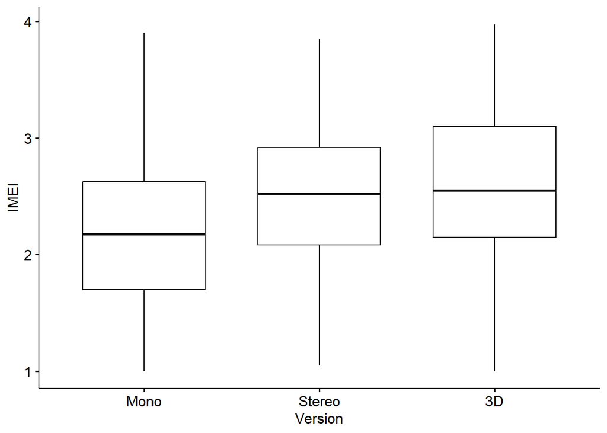

### Outliers

```r
imei_data_long_anova %>% group_by(version) %>% identify_outliers(imei)
```

```
## [1] version     participant imei        is.outlier  is.extreme
## <0 rows> (or 0-length row.names)
```

### Normality: Shapiro-Wilk Test and QQ-Plots

| Version | Test Statistic | $p$ |
| --- | --- | --- |
| Mono | 0.9791451 | 0.0061678 |
| Stereo | 0.9906810 | 0.2566218 |
| 3D | 0.9843966 | 0.0331309 |

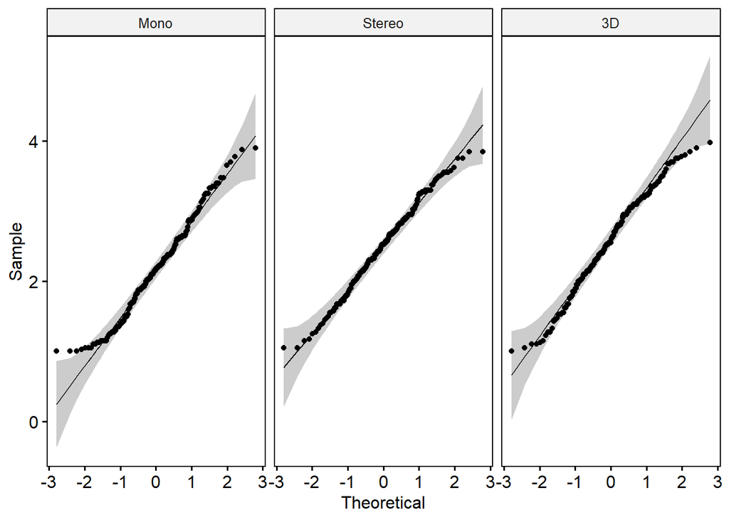

### Mauchly’s Test for Sphericity

| Effect | $W$ | $p$ | $p<.05$ |
| --- | --- | --- | --- |
| version | 0.687 | 0 | * |

| Effect | Grennhouse-Geisser $\epsilon$ | df(G-G) | $p$(G-G) | Huynh-Feldt $\epsilon$ | df(H-F) | $p$(H-F) |
| --- | --- | --- | --- | --- | --- | --- |
| version | 0.762 | 1.52, 287.95 | 0 | 0.767 | 1.53, 289.81 | 0 |

### Results

| Effect | DFn | DFd | $F$ | $p$ | $\eta^2_p$ | $\eta^2_G$ |
| --- | --- | --- | --- | --- | --- | --- |
| version | 1.52 | 287.95 | 89.882 | < .001 | 0.322 | 0.067 |

## IMEI CLEs

| Format 1 | Format 2 | CLE |
| --- | --- | --- |
| 3D | Stereo | 0.5861 |
| 3D | Mono | 0.7705 |
| Stereo | Mono | 0.7818 |

```r
p_3d <- .88 * prod(imei_cle_table$cle[imei_cle_table$format1 == "3D"]) + .11
```

Once again using the correction formula for multiple conditions from McGraw & Wong (1992), the CLE for 3D versus Stereo and Mono is 0.5073903.

# References

Corey, D. M., Dunlap, W. P., & Burke, M. J. (1998). Averaging correlations: Expected values and bias in combined pearson *r*s and Fisher’s *z* transformations. *The Journal of General Psychology*, *125*(3), 245–261. https://doi.org/10.1080/00221309809595548

Hahn, E. (2018). *Musical emotions evoked by 3D audio. Conference paper*. AES conference on spatial reproduction. http://www.aes.org/e-lib/browse.cfm?elib=19640

JASP Team. (2021). *JASP* (Version 16.0.0) [Computer software]. https://jasp-stats.org/

Lakens, D. (2013). Calculating and reporting effect sizes to facilitate cumulative science: A practical primer for t-tests and ANOVAs. *Frontiers in Psychology*, *4*. https://doi.org/10.3389/fpsyg.2013.00863

McGraw, K. O., & Wong, S. P. (1992). A common language effect size statistic. *Psychological Bulletin*, *111*(2), 361–365. https://doi.org/10.1037/0033-2909.111.2.361

Wycisk, Y., Sander, K., Kopiez, R., Platz, F., Preihs, S., & Peissig, J. (2022). Wrapped into sound: Development of the immersive music experience inventory (IMEI). *Frontiers in Psychology*. https://doi.org/10.3389/fpsyg.2022.951161